# United Kingdom Food CPI (Consumer Price Index)

Please complete the challenge using this [**quarto file**](https://byuistats.github.io/M335/presentations_class_palmer/code_challenges/challenge_template.qmd); it is just a blank file, but it has the YAML settings that will allow the instructor to see your output in the `.html` file you submit to I-learn after rendering.

## Background

This [article](https://medium.com/nightingale/covid-19-leads-to-a-drop-in-average-food-prices-in-the-uk-a6605a31cb0f) tracks the Consumer Price Index average food price in the United Kingdom. The author notes a drop in food prices in February 2020 and attributes that to the Coronoa Virus pandemic. She has 1 chart in her article.

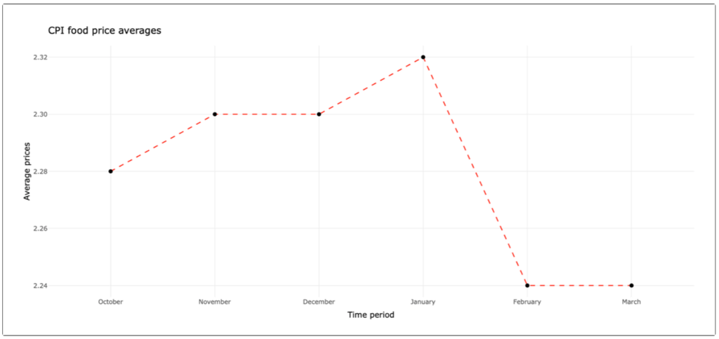

The data used to create that chart can be found in these excel files, one file for each month of data:

https://byuistats.github.io/M335/data/cpi_food_uk/cpiaverageprices201910.xlsx https://byuistats.github.io/M335/data/cpi_food_uk/cpiaverageprices201911.xlsx https://byuistats.github.io/M335/data/cpi_food_uk/cpiaverageprices201912.xlsx https://byuistats.github.io/M335/data/cpi_food_uk/cpiaverageprices202001.xlsx https://byuistats.github.io/M335/data/cpi_food_uk/cpiaverageprices202002.xlsx https://byuistats.github.io/M335/data/cpi_food_uk/cpiaverageprices202003.xlsx

## Deliverables

1. Using the datasets above, recreate the chart found in the web article
2. Some of the food items used to calculate the CPI changed starting in February 2020: some were removed and others were added. One could argue that the dip in the CPI was due to the change in items rather than a result of the Corona Virus. Create 1 or 2 excellent charts that investigate this hypothesis.
3. If you have time remaining, create a chart that tracks the individual items that experienced the most amount of change from the beginning to the end of the 6 month period.

**Submit the html file and the quarto file to I-learn.** Do not save your coding challenge work in your project or push it up to GitHub.